# Data Science Capstone Milestone Report

## Executive Summary

The purpose of this report is to investigate provided corpus data and see for the further opportunities for creating prediction model for predicting the text based on the already typed content. As it can be seen from the analysis below, provided corpus data is typical in the sense that:

- It contains a lot of noise like mistypes, UTF-16 encoded characters, foreign words, etc.
- Some of those can be easily filtered out by using simple regular expressions
- Many words repeat only few times throughout the corpus data
- A set of words is seen fairly often throughout corpus data and it matches the R definition of stop-words pretty much
- ~15,000 word dictionary covers 90% of the corpus words instances

## Analysis process

First we have to download, extract and perform initial analysis of the data.

```r
if (!file.exists("Coursera-SwiftKey.zip")){
    print("Downloading file ...")
    download.file(url = "https://d396qusza40orc.cloudfront.net/dsscapstone/dataset/Coursera-SwiftKey.zip",
        destfile = "Coursera-SwiftKey.zip", quiet = T)
}
if (!file.exists("./final/en_US/en_US.news.txt") ||
    !file.exists("./final/en_US/en_US.blogs.txt") ||
    !file.exists("./final/en_US/en_US.twitter.txt") ){
  print("Extracting archive ...")
  unzip(zipfile = "Coursera-SwiftKey.zip")
}
```

For some summary statistics we read the data as lines from the corresponding text files:

```r
#Cleans string data from numbers and special symbols
cleanString<-function(inputStr)
  {
    str<-tolower(inputStr)
    str<-gsub("[^a-zA-Z '-]", "", str)
    cleanString<-gsub("( ){2,}"," ", str)
  }
#Gets word count from a string
getWordCount<-function(line)
  {
    words<-strsplit(line, " ")[[1]]
    getWordCount<-length(words)
  }
#Reads the file from disk and cleans up the data
getLines<-function(fileName)
  {
    con<-file(fileName)
    lines<-readLines(con)
    close(con)
    print(paste("Sample data from: ", fileName))
    print(head(lines))
    getLines<-cleanString(lines)
  }
#Function that retrieves summary data from file
processLines<-function(lines)
  {
    lineCount<-length(lines)
    charSummary<-summary(nchar(lines))
    wordSummary<-summary(sapply(lines, getWordCount, simplify=T, USE.NAMES=F))
    processFile<-c(lineCount,
                   charSummary[1], charSummary[3], charSummary[4], charSummary[6],
                   wordSummary[1], wordSummary[3], wordSummary[4], wordSummary[6])
    names(processFile)<-c("Line Count",
                  "Min String Length", "Median String Length", "Mean String Length", "Max String Length",
                  "Min Word Count", "Meadian Word Count", "Mean Word Count", "Max Word Count")
    processFile
  }
twitterLines<-getLines("./final/en_US/en_US.twitter.txt")
```

```
## [1] "Sample data from:  ./final/en_US/en_US.twitter.txt"
## [1] "How are you? Btw thanks for the RT. You gonna be in DC anytime soon? Love to see you. Been way, way too long."
## [2] "When you meet someone special... you'll know. Your heart will beat more rapidly and you'll smile for no reason."
## [3] "they've decided its more fun if I don't."
## [4] "So Tired D; Played Lazer Tag & Ran A LOT D; Ughh Going To Sleep Like In 5 Minutes ;)"
## [5] "Words from a complete stranger! Made my birthday even better :)"
## [6] "First Cubs game ever! Wrigley field is gorgeous. This is perfect. Go Cubs Go!"
```

```r
newsLines<-getLines("./final/en_US/en_US.news.txt")
```

```
## [1] "Sample data from:  ./final/en_US/en_US.news.txt"
## [1] "He wasn't home alone, apparently."
## [2] "The St. Louis plant had to close. It would die of old age. Workers had been making cars there since the onset of mass automotive production in the 1920s."
## [3] "WSU's plans quickly became a hot topic on local online sites. Though most people applauded plans for the new biomedical center, many deplored the potential loss of the building."
## [4] "The Alaimo Group of Mount Holly was up for a contract last fall to evaluate and suggest improvements to Trenton Water Works. But campaign finance records released this week show the two employees donated a total of $4,500 to the political action committee (PAC) Partners for Progress in early…
## [5] "And when it's often difficult to predict a law's impact, legislators should think twice before carrying any bill. Is it absolutely necessary? Is it an issue serious enough to merit their attention? Will it definitely not make the situation worse?"
## [6] "There was a certain amount of scoffing going around a few years ago when the NFL decided to move the draft from the weekend to prime time -- eventually splitting off the first round to a separate day."
```

```r
blogLines<-getLines("./final/en_US/en_US.blogs.txt")
```

```
## [1] "Sample data from:  ./final/en_US/en_US.blogs.txt"
## [1] "In the years thereafter, most of the Oil fields and platforms were named after pagan ā€godsā€¯."
## [2] "We love you Mr. Brown."
## [3] "Chad has been awesome with the kids and holding down the fort while I work later than usual! The kids have been busy together playing Skylander on the XBox together, after Kyan cashed in his $$$ from his piggy bank. He wanted that game so bad and used his gift card from his birthday he has b…
## [4] "so anyways, i am going to share some home decor inspiration that i have been storing in my folder on the puter. i have all these amazing images stored away ready to come to life when we get our home."
## [5] "With graduation season right around the corner, Nancy has whipped up a fun set to help you out with not only your graduation cards and gifts, but any occasion that brings on a change in one's life. I stamped the images in Memento Tuxedo Black and cut them out with circle Nestabilities. I emb…
## [6] "If you have an alternative argument, let's hear it! :)"
```

```r
twitter<-processLines(twitterLines)
news<-processLines(newsLines)
blogs<-processLines(blogLines)
result<-cbind(twitter, news, blogs)
result
```

```
##                         twitter    news     blogs
## Line Count           2360148.00 77259.0 899288.00
## Min String Length          1.00     0.0      0.00
## Median String Length      61.00   178.0    150.00
## Mean String Length        65.07   193.7    222.00
## Max String Length        140.00  3288.0  39050.00
## Min Word Count             1.00     0.0      0.00
## Meadian Word Count        12.00    31.0     28.00
## Mean Word Count           12.52    33.5     41.07
## Max Word Count            47.00   544.0   6336.00
```

```r
#We might use lines later for the prediction model
lines<-c(twitterLines, newsLines, blogLines)
if (!file.exists("all-lines.rdata"))
  {
    save(lines, file="all-lines.rdata")
  }
twitterLines<-NULL
newsLines<-NULL
blogLines<-NULL
```

As one can see when reviewing original text data, it contains symbolic information (e.g. smileys, etc.), special notation (like RT for re-tweets), some special Unicode charachters like heart symbols, etc. Considering the task at hand, simple regular expression that looks for character symbols cleans the text pretty well. Predicting numbers, which could be any arbitraty number - is skipped in this solution, therefore regular expression exludes numbers as well. Punctuation may cause problems, therefore it is also removed, except apostrophes and dash as these symbols could be potentially part of the word.

Next step - to review distribution of the word usage in the corpus informations. This can be done by using DocumentTextMatrix from *tm* package.

```r
library(clue)
library(tm)
```

```r
library(reshape2)
library(ggplot2)
dirSource<-DirSource("./final/en_US/")
corpus<-Corpus(dirSource,
               readerControl = list(reader = readPlain,
                                      language = "en",
                                      load = TRUE))

corpus <- tm_map(corpus, removeNumbers)
corpus <- tm_map(corpus, removePunctuation, preserve_intra_word_dashes = TRUE)
corpus <- tm_map(corpus , stripWhitespace)
corpus <- tm_map(corpus, content_transformer(tolower))

if (file.exists("./dtm-analysis.rdata")) {
    load("dtm-analysis.rdata")
  } else {
    dtm<-DocumentTermMatrix(corpus,
                control=list(
                  wordLengths=c(1, Inf),
                  removeStopwords=FALSE,
                  language="english") )
    save(dtm, "dtm-analysis.rdata")

  }
wordMatrix <- as.matrix(dtm)
```

Let’s look into words extracted using tm package without regular expression based filtering:

```r
words <- colnames(wordMatrix)
head(words, 20)
```

```
##  [1] "\b\b\b\b"                       "\b\bźģ‚ķ™ė‹ė"
##  [3] "\bā€a"                         "\020"
##  [5] "\020flashback"                  "\035"
##  [7] "\035amazop"                     "\177"
##  [9] "-"                              "-he"
## [11] "-i"                             "-omgslap"
## [13] "-rt"                            "-so"
## [15] "-t"                             "-this"
## [17] "-word"                          "-z"
## [19] "–›ø"                            "–›ø•"
```

Total number of words without before filtering applied is:

```r
length(words)
```

```
## [1] 887564
```

As it is visible - data contains lot of non-vocabulary based notation. This can be filtered by applying regular expressions. This time we apply regular expressions to match any word that contains characters (a-z), dash (-) symbols and apostrophe (’). This would cover cases like:

```r
validCharWords<-words[regexpr(pattern = '^([a-zA-Z])(?!(\\1{1,}))[a-zA-Z]*([a-zA-Z]+-([a-zA-Z]){2,})?(\'(s)?)?$', words, perl=T )>0]
```

After filtering the sample words and the total count is the following:

```r
head(validCharWords, 20)
```

```
##  [1] "a"              "ab"             "ab-cd"          "ab-ed"
##  [5] "ab-extradition" "ab-fab"         "ab-ib"          "ab-inbev"
##  [9] "ab-inbevs"      "ab-only"        "ab-soul"        "ab-souls"
## [13] "ab-toning"      "aba"            "aba-based"      "abaa"
## [17] "abaaabab"       "abab"           "ababa"          "ababba"
```

```r
length(validCharWords)
```

```
## [1] 719291
```

Let’s look into the distribution of the words and their count in the corpus data. The plot below shows number of words vs. their frequency in the corpus.

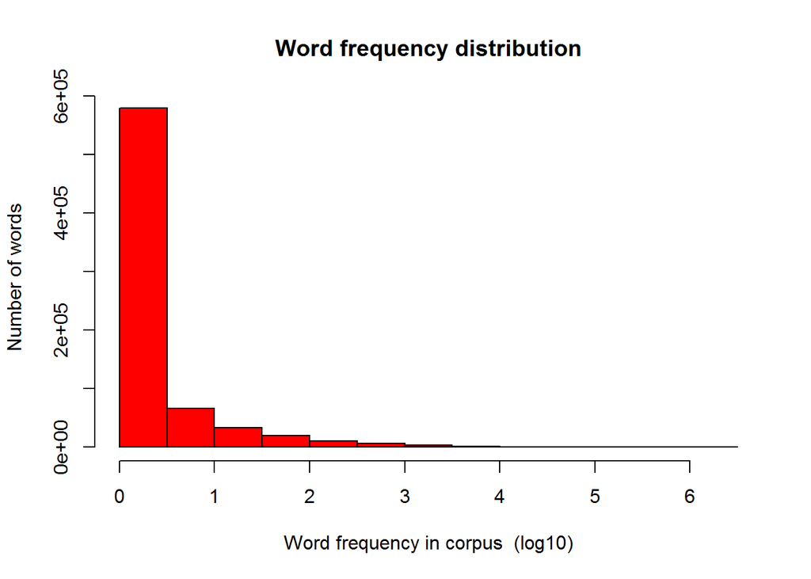

```r
validWordMatrix<-wordMatrix[,validCharWords]
validWordCount<-colSums(validWordMatrix)
hist(log10(validWordCount), xlab="Word frequency in corpus  (log10)", col = "red",
     ylab="Number of words", main = "Word frequency distribution")
```

Looking at low frequency words only, we see same overall picture.

```r
head(names(validWordCount[validWordCount<500]), 20)
```

```
##  [1] "ab-cd"          "ab-ed"          "ab-extradition" "ab-fab"
##  [5] "ab-ib"          "ab-inbev"       "ab-inbevs"      "ab-only"
##  [9] "ab-soul"        "ab-souls"       "ab-toning"      "aba"
## [13] "aba-based"      "abaa"           "abaaabab"       "abab"
## [17] "ababa"          "ababba"         "ababcba"        "ababng"
```

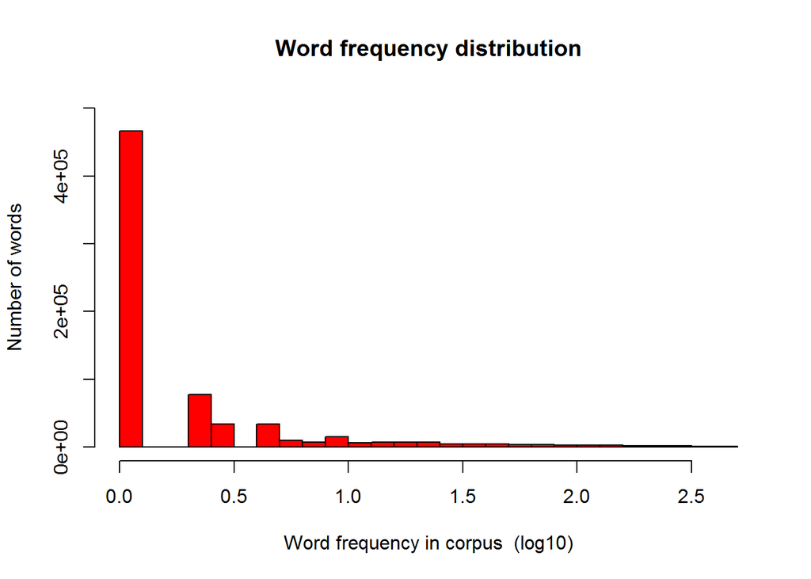

```r
hist(log10(validWordCount[validWordCount<500]), ylim = c(0, 5e+05),
     xlab="Word frequency in corpus  (log10)", col = "red",
     ylab="Number of words", main = "Word frequency distribution")
```

```r
print(paste("Out of ", length(validCharWords)," there are ", sum(validWordCount==1), " words that appear in the corpus once"))
```

```
## [1] "Out of  719291  there are  466417  words that appear in the corpus once"
```

Considering that total number of character based words in corpus is:

```r
totalWordsInCorpus<-sum(validWordCount)
totalWordsInCorpus
```

```
## [1] 67903656
```

Let’s compare what part of total corpus have words that have only single instance.

```r
singleWordStat<-rbind(
  c(sum(validWordCount>1), sum(validWordCount==1)),
  c(sum(validWordCount[validWordCount>1]), sum(validWordCount==1))
)
singleWordStat<-cbind(singleWordStat, c(singleWordStat[1,1]/singleWordStat[1,2], singleWordStat[2,1]/singleWordStat[2,2]))
colnames(singleWordStat)<-c("Instances>1","Instances==1", "Ratio")
rownames(singleWordStat)<-c("Unique words", "Total instances")
singleWordStat
```

```
##                 Instances>1 Instances==1       Ratio
## Unique words         252874       466417   0.5421629
## Total instances    67437239       466417 144.5857226
```

There are twice as many words that have a single instance in the text documents, but total number of words is 100 times less compared to other words that have more instances. And from the diagram it is obvious that there are few words with very high frequency of appearance in the documents. We can double-check how they match to the stop words for english language that are defined in R.

```r
length(validWordCount[validWordCount>200000])
```

```
## [1] 43
```

```r
setdiff(names(validWordCount[validWordCount>200000]), stopwords("english"))
```

```
## [1] "just" "like" "one"  "will"
```

Out of more than 40 words with higher than 200,000 frequency, only 4 words are not included in the standard stop-word list. Knowing that there are a lot of words that are represented only few times through the documents and the total word count is pretty large, there is a need to evaluate the possibility to select part of the corpus data for building the prediction model. Let’s see how many word instances we can cover by taking the words with highest frequency and adding them to the dictionary.

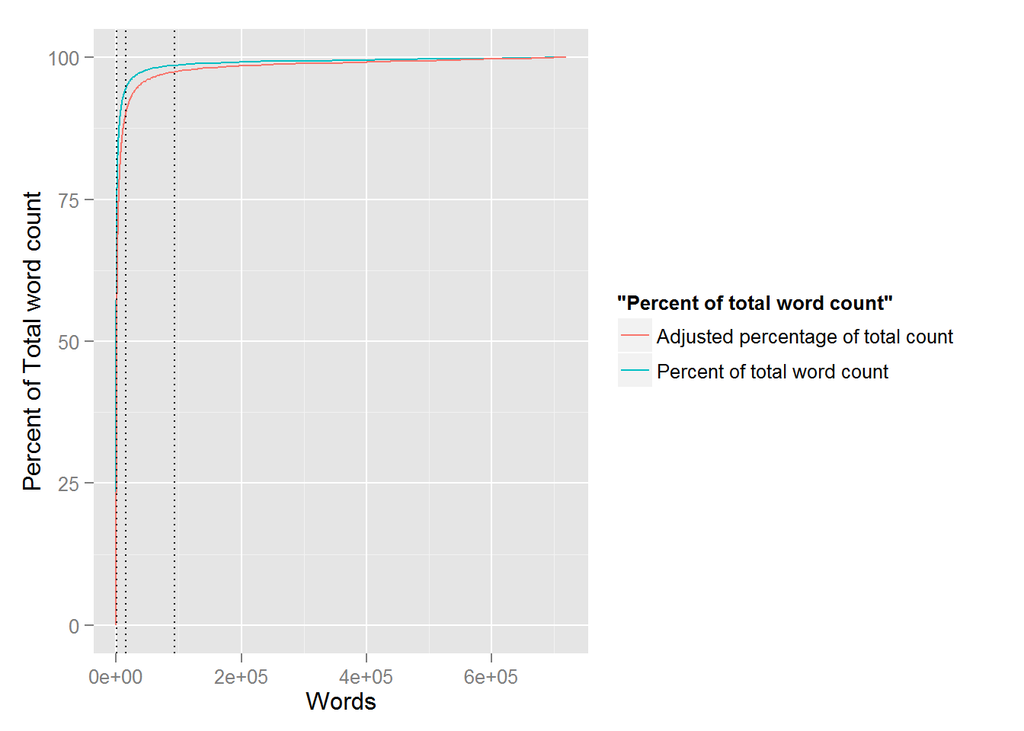

```r
stopWords<-intersect(validCharWords,stopwords("english"))
sortedWordCounts<-sort(validWordCount, decreasing=T)
sortedWordCounts<-rbind(
  c(1:length(sortedWordCounts)),
  sortedWordCounts,
  sortedWordCounts,
  cumsum(sortedWordCounts)
  )
sortedWordCounts[3, stopWords]<-0
totalAdjustedWordsInCorpus<-sum(sortedWordCounts[3, ])
sortedWordCounts<-rbind(sortedWordCounts, cumsum(sortedWordCounts[3,]))
sortedWordCounts<-rbind(sortedWordCounts,
                  round((sortedWordCounts[4,]/totalWordsInCorpus)*100,1),
                  round((sortedWordCounts[5,]/totalAdjustedWordsInCorpus)*100,1)
                  )
rownames(sortedWordCounts)<-c("Words", "Word instances", "Word instances adjusted",
                              "Cumulative sum of word instances", "Adjusted cumulative sum of word instances",
                              "Percent of Total word count", "Adjusted percentage of total count")
crossPoints<-c(
  sortedWordCounts[,sortedWordCounts[7,]>=50][1,1],
  sortedWordCounts[,sortedWordCounts[7,]>=90][1,1],
  sortedWordCounts[,sortedWordCounts[7,]>=97.5][1,1]
               )

ggplot(data=as.data.frame(t(sortedWordCounts)), aes(x=Words)) +
  geom_line(aes(y = `Percent of Total word count`, colour = "Percent of total word count")) +
  geom_line(aes(y = `Adjusted percentage of total count`, colour = "Adjusted percentage of total count")) +
  geom_vline(xintercept=crossPoints, linetype="dotted")
```

```r
crossPoints<-rbind(crossPoints, sortedWordCounts[2,crossPoints])
colnames(crossPoints)<-c("50%", "90%", "97.5%")
rownames(crossPoints)<-c("Words", "Word frequency")
crossPoints
```

```
##                 50%   90% 97.5%
## Words           890 14993 93480
## Word frequency 7690   193     7
```

By using 15,000 word size dictionary, we can cover 90% word usage in the provided corpus text. These words appear in the Corpus data more that 190 times, which means, we can take part of the data without loosing much information (and single instance words don’t help much either). 97.5% words can be matched by the 100,000 size dictionary, which is still 7x smaller that total size of the automatically generated dictionary. As visible from plot above, there is comparatively small increase in total word coverage, when using stop words in the dictionary. On the other hand, there are not so many of those, so if required later, we can include those during predictive model development.